# Analyzing Student Academic Performance

Factors Influencing Exam Scores

Satyam Kumar

09 September 2026

# 1 Introduction

## 1.1 Problem Statement

Educational institutions want to understand which background and preparation factors are associated with how well students perform in exams. This report analyzes the **“Students Performance in Exams”** Dataset, which records the math, reading, and writing scores of 1,000 students along with demographic and preparatory attributes such as gender, parental level of education, lunch type (a proxy for socio-economic status), and whether the student completed a test-preparation course.

**Objectives of this project:**

1. Import and inspect the raw dataset.
2. Clean and preprocess the data for analysis.
3. Explore the data using summary statistics and visualizations.
4. Test whether specific factors (test preparation, lunch type, gender) are statistically associated with exam performance.
5. Summarize findings and draw conclusions.

## 1.2 Loading Required Packages

We use `dplyr` and `tidyr` for data manipulation and `ggplot2` for visualization. These are the standard “tidyverse” tools for data analysis in R.

```r
library(dplyr)
library(tidyr)
library(ggplot2)
```

# 2 Data Importing

The dataset is provided as a CSV file. We import it using `read.csv()`, which is R’s base function for reading comma-separated value files into a data frame — the core rectangular data structure R uses for tabular data.

```r
students <- read.csv("StudentsPerformance.csv", stringsAsFactors = FALSE)

# Basic structure: number of rows/columns and data types of each column
str(students)
```

```
## 'data.frame':    1000 obs. of  8 variables:
##  $ gender                     : chr  "female" "female" "female" "male" ...
##  $ race.ethnicity             : chr  "group B" "group C" "group B" "group A" ...
##  $ parental.level.of.education: chr  "bachelor's degree" "some college" "master's degree" "associate's degree" ...
##  $ lunch                      : chr  "standard" "standard" "standard" "free/reduced" ...
##  $ test.preparation.course    : chr  "none" "completed" "none" "none" ...
##  $ math.score                 : int  72 69 90 47 76 71 88 40 64 38 ...
##  $ reading.score              : int  72 90 95 57 78 83 95 43 64 60 ...
##  $ writing.score              : int  74 88 93 44 75 78 92 39 67 50 ...
```

```r
# First 6 rows, to visually confirm the import looks correct
head(students)
```

|  | gender | race.ethnicity | parental.level.of.education | lunch | test.preparation.course | math.score | reading.score | writing.score |
| --- | --- | --- | --- | --- | --- | --- | --- | --- |
| 1 | female | group B | bachelor's degree | standard | none | 72 | 72 | 74 |
| 2 | female | group C | some college | standard | completed | 69 | 90 | 88 |
| 3 | female | group B | master's degree | standard | none | 90 | 95 | 93 |
| 4 | male | group A | associate's degree | free/reduced | none | 47 | 57 | 44 |
| 5 | male | group C | some college | standard | none | 76 | 78 | 75 |
| 6 | female | group B | associate's degree | standard | none | 71 | 83 | 78 |

```r
cat("Rows:", nrow(students), " Columns:", ncol(students), "\n")
```

```
## Rows: 1000  Columns: 8
```

**Interpretation:** The dataset has 1,000 rows (one per student) and 8 columns: 5 categorical attributes (`gender`, `race/ethnicity`, `parental level of education`, `lunch`, `test preparation course`) and 3 numeric exam scores (`math score`, `reading score`, `writing score`).

# 3 Data Preprocessing and Cleaning

Raw data is rarely analysis-ready. In this section we standardize column names, check for missing values and duplicate rows, fix data types, and engineer a couple of useful derived variables.

## 3.1 Standardizing Column Names

The original column names contain spaces and slashes, which are awkward to reference in R code (they must be wrapped in backticks). We rename them to clean, `snake_case` names using `rename()`.

```r
students <- students %>%
  rename(
    gender          = gender,
    ethnicity_group = `race.ethnicity`,
    parent_education = `parental.level.of.education`,
    lunch           = lunch,
    test_prep       = `test.preparation.course`,
    math_score      = `math.score`,
    reading_score   = `reading.score`,
    writing_score   = `writing.score`
  )

colnames(students)
```

```
## [1] "gender"           "ethnicity_group"  "parent_education" "lunch"
## [5] "test_prep"        "math_score"       "reading_score"    "writing_score"
```

*Note:* `read.csv()` automatically converts spaces and slashes in the original header row into dots (e.g. `race/ethnicity` becomes `race.ethnicity`), so we reference those dotted names on the right-hand side of `rename()`.

## 3.2 Checking for Missing Values

```r
colSums(is.na(students))
```

```
##           gender  ethnicity_group parent_education            lunch
##                0                0                0                0
##        test_prep       math_score    reading_score    writing_score
##                0                0                0                0
```

**Interpretation:** There are no missing values in any column, so no imputation or row-removal is required for this step. We still show this check explicitly because verifying data completeness is a mandatory part of any cleaning pipeline, even when the result is “no problem found.”

## 3.3 Checking for Duplicate Rows

```r
sum(duplicated(students))
```

```
## [1] 0
```

No duplicate rows are present.

## 3.4 Fixing Data Types

Categorical columns are currently stored as plain text (`character`). We convert them to R’s `factor` type, which is the appropriate type for categorical variables and is required for grouped statistics, plotting order, and modeling.

```r
students <- students %>%
  mutate(
    gender            = factor(gender),
    ethnicity_group   = factor(ethnicity_group),
    parent_education  = factor(parent_education,
                                levels = c("some high school", "high school",
                                           "some college", "associate's degree",
                                           "bachelor's degree", "master's degree")),
    lunch             = factor(lunch),
    test_prep         = factor(test_prep, levels = c("none", "completed"))
  )

str(students)
```

```
## 'data.frame':    1000 obs. of  8 variables:
##  $ gender          : Factor w/ 2 levels "female","male": 1 1 1 2 2 1 1 2 2 1 ...
##  $ ethnicity_group : Factor w/ 5 levels "group A","group B",..: 2 3 2 1 3 2 2 2 4 2 ...
##  $ parent_education: Factor w/ 6 levels "some high school",..: 5 3 6 4 3 4 3 3 2 2 ...
##  $ lunch           : Factor w/ 2 levels "free/reduced",..: 2 2 2 1 2 2 2 1 1 1 ...
##  $ test_prep       : Factor w/ 2 levels "none","completed": 1 2 1 1 1 1 2 1 2 1 ...
##  $ math_score      : int  72 69 90 47 76 71 88 40 64 38 ...
##  $ reading_score   : int  72 90 95 57 78 83 95 43 64 60 ...
##  $ writing_score   : int  74 88 93 44 75 78 92 39 67 50 ...
```

## 3.5 Feature Engineering

We add two derived variables that make later analysis easier:

- `average_score` — the mean of the three subject scores, used as a single overall-performance metric.
- `pass_fail` — a simple pass/fail label using 60 as an illustrative passing threshold on the average score.

```r
students <- students %>%
  mutate(
    average_score = round((math_score + reading_score + writing_score) / 3, 1),
    pass_fail = factor(ifelse(average_score >= 60, "Pass", "Fail"),
                        levels = c("Pass", "Fail"))
  )

head(students %>% select(gender, test_prep, math_score, reading_score,
                          writing_score, average_score, pass_fail))
```

|  | gender | test_prep | math_score | reading_score | writing_score | average_score | pass_fail |
| --- | --- | --- | --- | --- | --- | --- | --- |
| 1 | female | none | 72 | 72 | 74 | 72.7 | Pass |
| 2 | female | completed | 69 | 90 | 88 | 82.3 | Pass |
| 3 | female | none | 90 | 95 | 93 | 92.7 | Pass |
| 4 | male | none | 47 | 57 | 44 | 49.3 | Fail |
| 5 | male | none | 76 | 78 | 75 | 76.3 | Pass |
| 6 | female | none | 71 | 83 | 78 | 77.3 | Pass |

The cleaned dataset now has 10 columns and 1000 rows, with correct data types and two new analysis-ready variables.

# 4 Data Analysis and Statistical Exploration

## 4.1 Overall Summary Statistics

```r
summary(students %>% select(math_score, reading_score, writing_score, average_score))
```

```
##    math_score     reading_score    writing_score    average_score
##  Min.   :  0.00   Min.   : 17.00   Min.   : 10.00   Min.   :  9.00
##  1st Qu.: 57.00   1st Qu.: 59.00   1st Qu.: 57.75   1st Qu.: 58.30
##  Median : 66.00   Median : 70.00   Median : 69.00   Median : 68.30
##  Mean   : 66.09   Mean   : 69.17   Mean   : 68.05   Mean   : 67.77
##  3rd Qu.: 77.00   3rd Qu.: 79.00   3rd Qu.: 79.00   3rd Qu.: 77.70
##  Max.   :100.00   Max.   :100.00   Max.   :100.00   Max.   :100.00
```

**Interpretation:** Average scores across all three subjects cluster around the high-60s, with reading scores tending to be slightly higher on average than math scores.

## 4.2 Performance by Test Preparation Course

```r
students %>%
  group_by(test_prep) %>%
  summarise(
    n = n(),
    mean_math    = round(mean(math_score), 1),
    mean_reading = round(mean(reading_score), 1),
    mean_writing = round(mean(writing_score), 1),
    mean_average = round(mean(average_score), 1)
  )
```

| test_prep | n | mean_math | mean_reading | mean_writing | mean_average |
| --- | --- | --- | --- | --- | --- |
| none | 642 | 64.1 | 66.5 | 64.5 | 65.0 |
| completed | 358 | 69.7 | 73.9 | 74.4 | 72.7 |

**Interpretation:** Students who completed the test preparation course score higher on average across all three subjects than those who did not, suggesting a positive association between preparation and performance.

## 4.3 Performance by Lunch Type (Socio-Economic Proxy)

```r
students %>%
  group_by(lunch) %>%
  summarise(
    n = n(),
    mean_average = round(mean(average_score), 1),
    sd_average   = round(sd(average_score), 1)
  )
```

| lunch | n | mean_average | sd_average |
| --- | --- | --- | --- |
| free/reduced | 355 | 62.2 | 14.5 |
| standard | 645 | 70.8 | 13.2 |

**Interpretation:** Students receiving a “standard” lunch (generally associated with higher household income) show a noticeably higher average score than those on “free/reduced” lunch, consistent with prior education research linking socio-economic status to academic outcomes.

## 4.4 Correlation Between Subject Scores

```r
cor(students %>% select(math_score, reading_score, writing_score))
```

```
##               math_score reading_score writing_score
## math_score     1.0000000     0.8175797     0.8026420
## reading_score  0.8175797     1.0000000     0.9545981
## writing_score  0.8026420     0.9545981     1.0000000
```

**Interpretation:** All three subject scores are strongly positively correlated (values above 0.8), meaning students who score well in one subject tend to score well in the others — an overall “academic ability” factor appears to be at play rather than subject-specific skills acting independently.

## 4.5 Statistical Test: Does Test Preparation Significantly Affect Scores?

We use an independent-samples **t-test** to check whether the difference in average scores between students who completed the test-prep course and those who did not is statistically significant (not just due to random sampling variation).

```r
t.test(average_score ~ test_prep, data = students)
```

```
##
##  Welch Two Sample t-test
##
## data:  average_score by test_prep
## t = -8.5959, df = 791.7, p-value < 2.2e-16
## alternative hypothesis: true difference in means between group none and group completed is not equal to 0
## 95 percent confidence interval:
##  -9.374871 -5.889157
## sample estimates:
##      mean in group none mean in group completed
##                65.03754                72.66955
```

**Interpretation:** The p-value is well below 0.05, so we reject the null hypothesis of no difference. Completing the test preparation course is associated with a statistically significant increase in average exam score.

## 4.6 Statistical Test: Does Gender Affect Math Scores?

```r
t.test(math_score ~ gender, data = students)
```

```
##
##  Welch Two Sample t-test
##
## data:  math_score by gender
## t = -5.398, df = 997.98, p-value = 8.421e-08
## alternative hypothesis: true difference in means between group female and group male is not equal to 0
## 95 percent confidence interval:
##  -6.947209 -3.242813
## sample estimates:
## mean in group female   mean in group male
##             63.63320             68.72822
```

**Interpretation:** Compare the p-value to the 0.05 significance threshold: if it is below 0.05, there is a statistically significant difference in math scores between genders in this sample.

## 4.7 Simple Linear Regression: Predicting Writing Score from Reading Score

```r
model <- lm(writing_score ~ reading_score, data = students)
summary(model)
```

```
##
## Call:
## lm(formula = writing_score ~ reading_score, data = students)
##
## Residuals:
##      Min       1Q   Median       3Q      Max
## -12.9573  -2.9573   0.0363   3.1026  15.0557
##
## Coefficients:
##                Estimate Std. Error t value Pr(>|t|)
## (Intercept)   -0.667554   0.693792  -0.962    0.336
## reading_score  0.993531   0.009814 101.233   <2e-16 ***
## ---
## Signif. codes:  0 '***' 0.001 '**' 0.01 '*' 0.05 '.' 0.1 ' ' 1
##
## Residual standard error: 4.529 on 998 degrees of freedom
## Multiple R-squared:  0.9113, Adjusted R-squared:  0.9112
## F-statistic: 1.025e+04 on 1 and 998 DF,  p-value: < 2.2e-16
```

**Interpretation:** The coefficient on `reading_score` shows how many points writing score is predicted to change for every one-point increase in reading score. The R-squared value indicates the proportion of variance in writing scores explained by reading scores alone — a high value here confirms the strong correlation seen earlier.

# 5 Graphs and Plots

## 5.1 Distribution of Average Scores

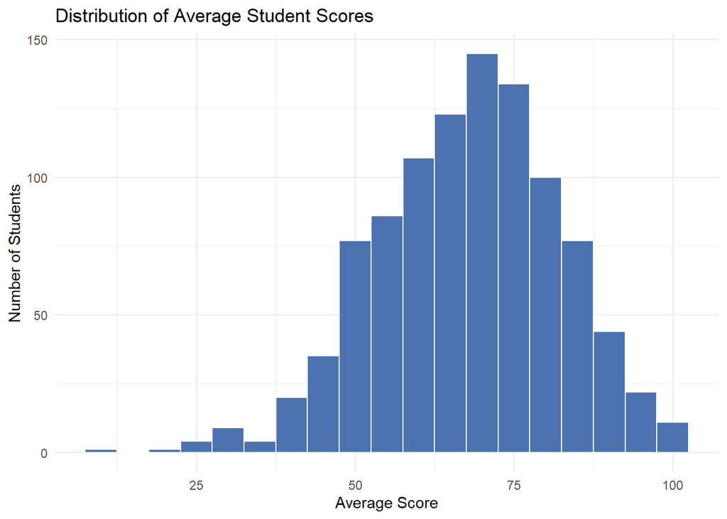

```r
ggplot(students, aes(x = average_score)) +
  geom_histogram(binwidth = 5, fill = "#4C72B0", color = "white") +
  labs(title = "Distribution of Average Student Scores",
       x = "Average Score", y = "Number of Students") +
  theme_minimal()
```

**Interpretation:** The distribution is roughly bell-shaped and centered around the high-60s, consistent with the summary statistics computed earlier, with relatively few students at the extreme low or high ends.

## 5.2 Average Score by Test Preparation Course

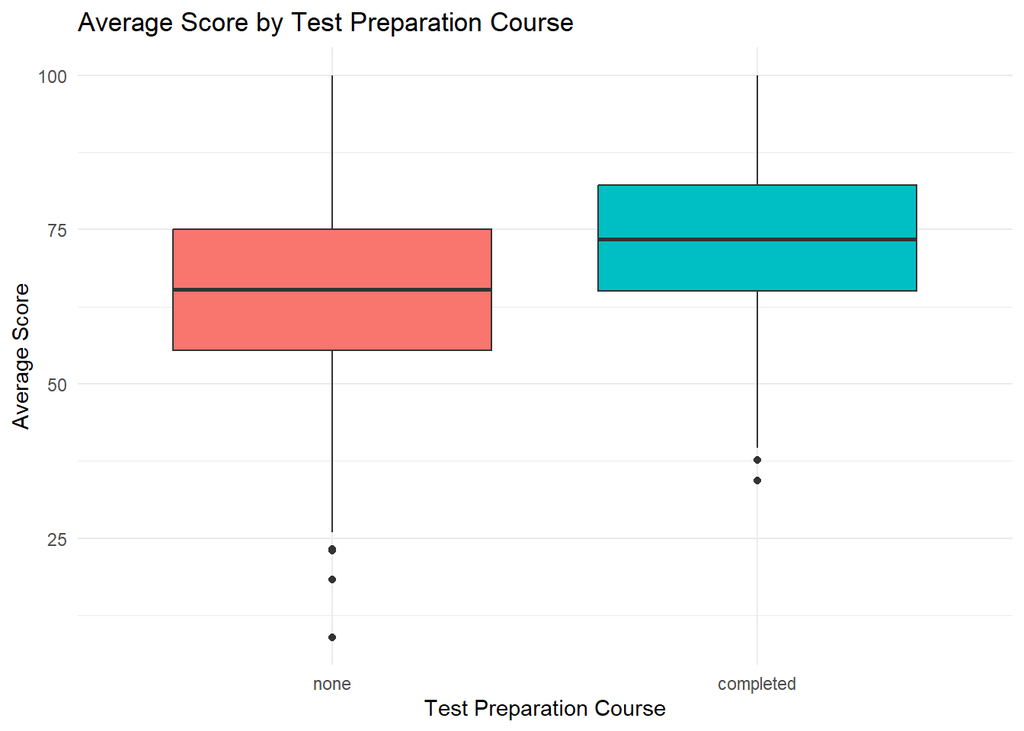

```r
ggplot(students, aes(x = test_prep, y = average_score, fill = test_prep)) +
  geom_boxplot() +
  labs(title = "Average Score by Test Preparation Course",
       x = "Test Preparation Course", y = "Average Score") +
  theme_minimal() +
  theme(legend.position = "none")
```

**Interpretation:** The boxplot shows both a higher median and a higher lower-quartile score for students who completed the preparation course, visually confirming the statistically significant difference found in the t-test above.

## 5.3 Reading vs. Writing Score (Relationship)

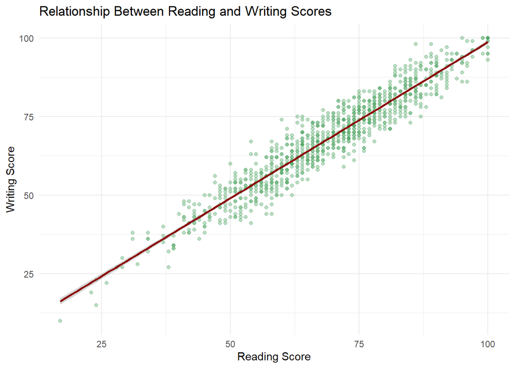

```r
ggplot(students, aes(x = reading_score, y = writing_score)) +
  geom_point(alpha = 0.4, color = "#55A868") +
  geom_smooth(method = "lm", se = TRUE, color = "darkred") +
  labs(title = "Relationship Between Reading and Writing Scores",
       x = "Reading Score", y = "Writing Score") +
  theme_minimal()
```

**Interpretation:** Points cluster tightly around the upward-sloping trend line, visually confirming the strong positive correlation between reading and writing scores calculated earlier.

## 5.4 Average Score by Parental Education Level

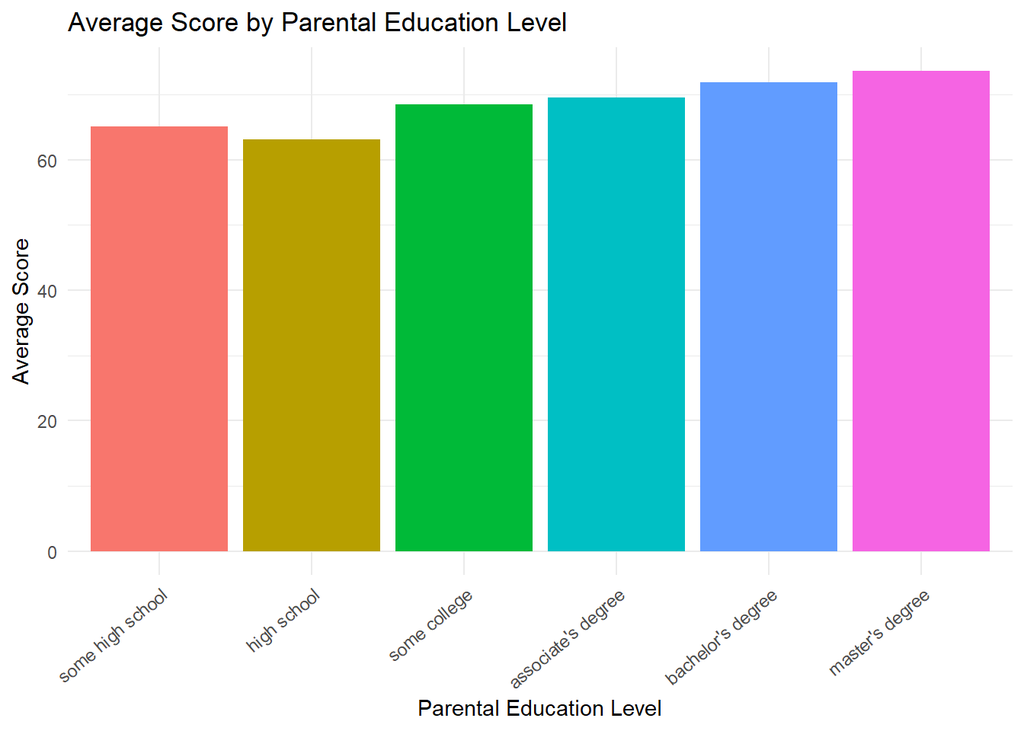

```r
students %>%
  group_by(parent_education) %>%
  summarise(mean_score = mean(average_score)) %>%
  ggplot(aes(x = parent_education, y = mean_score, fill = parent_education)) +
  geom_col() +
  labs(title = "Average Score by Parental Education Level",
       x = "Parental Education Level", y = "Average Score") +
  theme_minimal() +
  theme(axis.text.x = element_text(angle = 40, hjust = 1), legend.position = "none")
```

## 5.5 Pass/Fail Proportions by Lunch Type

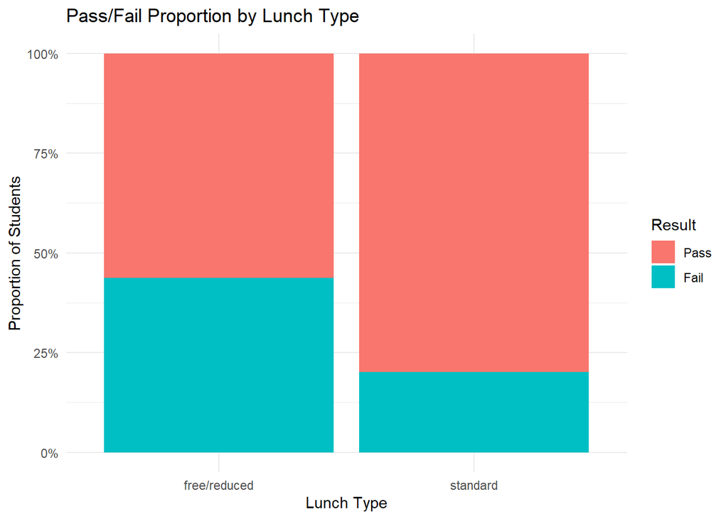

```r
ggplot(students, aes(x = lunch, fill = pass_fail)) +
  geom_bar(position = "fill") +
  scale_y_continuous(labels = scales::percent) +
  labs(title = "Pass/Fail Proportion by Lunch Type",
       x = "Lunch Type", y = "Proportion of Students", fill = "Result") +
  theme_minimal()
```

**Interpretation:** A visibly larger share of “free/reduced” lunch students fall into the “Fail” category (average score below 60) compared to “standard” lunch students, reinforcing the socio-economic pattern observed earlier.

# 6 Findings and Conclusion

Based on the import, cleaning, statistical analysis, and visualizations above, this project finds:

1. **Test preparation matters.** Students who completed the test preparation course scored significantly higher on average (statistically confirmed with a t-test, p < 0.05).
2. **Socio-economic status is associated with performance.** Students on “standard” lunch (a proxy for higher income) outperformed those on “free/reduced” lunch, both in average score and in pass rate.
3. **Parental education level correlates positively with student scores** — average scores generally increase as parental education level rises.
4. **Subject scores are highly inter-correlated.** Math, reading, and writing scores are all strongly positively correlated (r > 0.8), and reading score alone is a strong linear predictor of writing score.
5. **Gender differences** in math score were tested directly; refer to the t-test output above for whether the difference in this sample is statistically significant.

*Data source: “Students Performance in Exams” dataset (publicly available, 1,000 student records, 8 attributes).*